# Source Code for Websites: HTML, CSS, and Javascript

PS239T  
Spring 2018

### Why HTML?

Understanding the basic structure of HTML (and two other languages often used to customize websites, CSS and Javascript) allows us to:

- pursue data collection projects that entail webscraping
- improve the design of our own websites (you have one, right?)
- evaluate how best to share our findings with a web-based audience

### Learning Objectives

- understand enough HTML structure to build a scraper (next week)
- discern what components of a webpage are relevant to that task (HTML, Javascript) and which probably are not (CSS)

### What is a Website?

Some combination of codebase, database

The “front end” product is HTML + CSS stylesheets + Javascript

- HTML:
  - provides the skeleton of the website (aka, the “tree”)
  - starts with call to `<html>` tag, ends with `</html>` tag
- CSS:
  - fleshes out the website (provides color, shape, styling, etc.)
  - uses *.css files or code embedded in `<style>` `</style>` or `<link>` `</link>` tags
- Javascript:
  - brings the website to life (dynamic or interactive content)
  - *.js files or code embedded in `<script>` `</script>` tags

### This is a Website

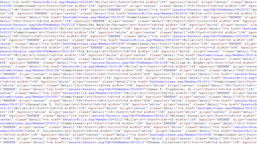

Your browser turns that into a tidy layout…

### This is What You Think a Website Is

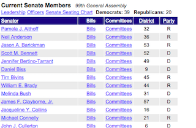

Voila!

### HTML: Basic Structure

```html
<!DOCTYPE html>
<html>
    <head>
        <title>Page title</title>
    </head>
    <body>
        <p>Hello world!</p>
    </body>
</html>
```

### HTML is a Tree

[figure not shown]

Where else have we seen a tree structure before?

### Document Object Model

- Most modern browsers have a parser that reads in the HTML document, parses it into a DOM (Document Object Model) structure, and then renders the DOM structure.
- Much like HTTP, the DOM is an agreed-upon standard.
- The DOM is much more than what I've described, but for our purposes, what is most important to understand is that the text is only one part of an HTML element. (This will be important to remember when you get to writing your scrapers next week!)

### Example of a Document Object Model

Note that the DOM retains the tree structure:

[figure not shown]

### HTML Elements

Generally speaking, an HTML element has three components:

1. Tags (starts and ends the element)
2. Attributes (gives information about the element)
3. Content (the text/image/etc. *inside* the element)

[figure not shown]

### HTML: Tags

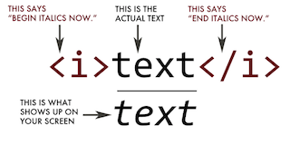

[Image credit](http://miriamposner.com/blog/wp-content/uploads/2011/11/html-handout.pdf)

### Common HTML Tags

| Tag | Meaning |
| --- | --- |
| `<head>` | page header (metadata, etc |
| `<body>` | holds all of the content |
| `<p>` | regular text (paragraph) |
| `<h1>`,`<h2>`,`<h3>` | header text, levels 1, 2, 3 |
| `ol,`,`<ul>`,`<li>` | ordered list, unordered list, list item |
| `<a href="page.html">` | link to “page.html” |
| `<table>`,`<tr>`,`<td>` | table, table row, table item |
| `<div>`,`<span` | general containers |

### HTML Attributes

- HTML elements can have attributes
- Attributes provide additional information about an element
- Attributes are always specified in the start tag
- Attributes come in name/value pairs like: name=“value”

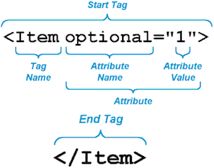

### CSS

- CSS = Cascading Style Sheet.
- CSS defines how HTML elements are to be displayed
- HTML came first. But it was only meant to define content, not format it. While HTML contains tags like `<font>` and `<color>`, this is a very inefficient way to develop a website.
- To solve this problem, CSS was created to display content on a webpage. Now, one can change the look of an entire website just by changing one file.
- Most web designers litter the HTML markup with tons of `class`s and `id`s to provide “hooks” for their CSS.
- You can piggyback on these to jump to the parts of the markup that contain the data you need.

### CSS Anatomy

- Selectors
  - Element selector: `p`
  - Class selector: `p class="blue"`
  - I.D. selector: `p id="blue"`
- Declarations
  - Selector: `p`
  - Property: `background-color`
  - Value: `yellow`
- Hooks

[figure not shown]

### CSS + HTML

```html
<body>
    <table id="content">
        <tr class='name'>
            <td class='firstname'>
                Ernesto
            </td>
            <td class='lastname'>
                Rojas
            </td>
        </tr>
        <tr class='name'>
            <td class='firstname'>
                Elisabeth
            </td>
            <td class='lastname'>
                Earley
            </td>
        </tr>
    </table>
</body>
```

### Javascript

- Where have we seen Javascript before?
  - .json = **J**ava**s**cript **O**bject **N**otation
  - Note: Javascript and Java are two entirely separate languages
- Javascript is added into existing HTML code (either in head or in body)
- JS adds actions to sites: every time you “interact” with a button, image, or graphic, or you see something change live, you're probably looking at Javascript

### Javascript Example 1

Javascript can be added explicitly in code, or by calling a separate script file (.js)

- Added explicitly:

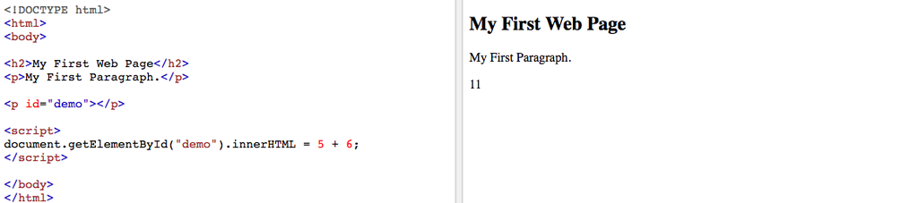

  [Image credit](https://www.w3schools.com/js/js_output.asp)

### Javascript Example 2

Javascript can also be written as a separate script, just like we do with R (and it looks fairly similar!)

```javascript
var x, y;
x = 5;
y = 'string' // This is a string
z = x + y;
```

What will z print?

### Return of the Javascript

We'll come back to Javascript when we get to Qualtrics, in a few weeks!

For now, it's time for a challenge…

### Assemble Your Tools

1. Get the [Selector Gadget](http://selectorgadget.com/)
   - this is a Chrome extension that lets us select everything on a page of a certain type (typically, by looking for objects of the same class)
2. Head to the [New York Times](http://www.nytimes.com/)
3. Prepare your right fingers (aka, find your right-click functionality using a mouse or trackpad!)

### Inspect Element

Google Chrome comes with great developer tools to help parse a webpage.

[figure not shown]

The inspector gives you the HTML tree, as well as all the CSS selectors and style information.

### Challenges

1. What tags uniquely define the byline? What is the CSS selector for the byline?
2. What tags uniquely define the section headers? Is there a CSS selector for all the section headers?
3. Using the styles tab in your inspector, change all headlines to a “blueviolet” color. Change the page background color to “bisque.”
4. Change the font size of the summaries to be smaller. Change the font family of the text for the summaries. Then, change it for the entire page.
5. What tags define links to the articles?
6. What is the first instance of Javascript on the webpage?